# k-means_methodes

Aziliz

2025-06-04

# Documentation à propos du clustering

https://www.tidymodels.org/learn/statistics/k-means/

Comment fonctionne le K-means ? But : assigner chaque observation à un cluster k

```
1- Spécifier le nombre de clusters
2- Chaque observation seule est assignée temporairement à un centroïde qui lui est proche
3- Le centroïde de chaque cluster est calculé selon l'ensemble des observations assignées au cluster
```

Nb : les centroïdes des clusters peuvent bouger => réassigner certaines observations à un centroïde devenu plus proche

**= processus itératif de calcul des centroïdes et d’assignation des observation à celui qui leur est le plus proche** **STOP : quand plus rien ne bouge** **=> chaque observation est assignée à son cluster final !**

Practical Guide To Cluster Analysis in R - Alboukadel Kassambara https://xsliulab.github.io/Workshop/2021/week10/r-cluster-book.pdf

**But du clustering** = identifier des groupes d’objets similaires au sein d’un ensemble de données

**K-means clustering** (MacQuenn, 1967) : algorithme d’apprentissage automatique le plus couramment utilisé pour partitionner un ensemble de données en un ensemble de k clusters. Chaque cluster est représenté par son centre (*centroid*) = les principaux points assignés au cluster. - (chapitre 4)

Nb : utilisation des moyennes comme centre des clusters

Comment définir un cluster ? Plusieurs méthodes et algorithmes possible mais le plus utilisé : * le Hartigan-Wong algorithme : intérieur d’un cluster = somme des carrés des distances euclidiennes entre les éléments et le centroïde correspondant

**Fonctionnement général du clustering (K-means) : assignation de chaque observation à un cluster –> calcul de la valeur principal de chaque cluster (centroid) –> vérification par l’algorithme que chaque observation est bien dans le cluster le plus proche d’un centroïde –> réassignation si ce n’est pas le cas –> modification des clusters –> nouveau calcul des centroïdes des clusters …**

Etape 1 : indiquer le nombre de clusters qui seront générés dans le solution finale

Comment choisir le bon nombre de clusters k que l’on veut au final? –> fonction **fviz_nbclust()** = solution efficace pour estimer le nombre optimal de clusters

=> kmeans(df, 4 (= nombre de clusters k), nstart = n) Nb : mieux vaut indiquer un grand nombre (25, 50) pour *nstart* pour avoir une plus grande stabilité. *Nstart* : choix de n assignations de départ et R garde celle avec la variance la plus faible au sein du cluster

Tirer un graphique de cela il faut utiliser le **PCA** (Principal Component Analysis) pour réduire le nombre de dimension des données qui ont plus de 2 variables. But : faire un graphique en se basant sur les coordonnées des deux composantes principales

- **K-Medoids** = chaque cluster est représenté par l’un des points qu’il contient (*medoid*)

Medioïde = objet au sein d’une grappe pour lequel la dissimilarité moyenne entre lui et tous les autres membres de la grappe est minimale

Algorithme principalement utilisé : **PAM** (Partitioning Around Medoids, Kaufman et Rousseeuw - 1990) - (chapitre 5)

Nb : pour les grands jeux de données mieux vaut privilégier l’utilisation de l’algorithme **CLARA** (chapitre 6)

Comment fonctionne cet algorithme ? 1. Sélectionne k objets qui deviendront les médioïdes

2. Calcul de la matrice de dissimilarité si elle n’a pas été fournie
3. Affecte chaque objet à son médioïde le plus proche
4. Pour chaque grappe, recherche si l’un des objets de la grappe diminue le coefficient de dissimilarité moyen ; si c’est le cas, sélectionne l’entité qui diminue ce coefficient.
5. Si au moins un médoïde a changé, retour à (3), sinon fin l’algorithme.

L’algorithme PAM demande à l’utilisateur de connaître les données et d’indiquer le nombre approprié de grappes à produire. Ce nombre peut être estimé à l’aide de la fonction **fviz_nbclust** [dans le paquetage R de *factoextra*].

Après avoir effectué le regroupement PAM, la fonction R **fviz_cluster()** [paquet factoextra] peut être utilisée pour visualiser les résultats. Le format est **fviz_cluster(pam.res)**, où pam.res est le résultat du PAM.

# Objectifs avec la méthode du clustering

1- Grouper les communes par spécialité de production agricole

2- Comprendre la signification de ces groupes (comment l’algorithme en est arrivée là)

3- Construire une carte des communes représentant les spécifications (par un code couleur par exemple)

# Mise en application du clustering

## Préparation de l’environnement

```
##          used (Mb) gc trigger (Mb) max used (Mb)
## Ncells 541363 29.0    1203522 64.3   686457 36.7
## Vcells 990768  7.6    8388608 64.0  1876289 14.4
```

[output not shown]

## Détermination du nombre de clusters optimal

NB : subjectif, dépend de la méthode employées pour mesurer les similarités entre les paramètres : méthodes directes (`elbow` and `silhouette`) ou méthode de test statistique (`gap statistic`)

- `Elbow method` : faire varier le nombre de clusters k entre 1 et 10 et pour chaque k le WSS (mesure la compacité du regroupement). Le but est ensuite d’en tirer un graphique, k-optimal sera indiqué par une courbure, un “coude”.
- `Average silhouette method` : mesure la qualité d’un clustering (un indice élevé indique l’optimalité du clustering) A l’inverse de “Elbow”, ici, le k-optimal sur le graphique sera le maximum de la courbe.
- `Gap statistic method` : comapraison des variations à l’intérieur des “grappes” pour différentes valeurs de k avec leurs valeurs attendues dans le cadre d’une distribution de référence des valeurs. k-optimal = valeur qui maximise le “gap statistic”

Maintenant, le but est de l’automatiser pour qu’il soit calculer dans le script et que la suite du script s’en serve automatiquement pour construire les clusters.

## Application de la méthode CLARA à partir du manuel d’Alboukadel Kassambara

Raisonnement : - nettoyer les données - garder seulement les données numériques - standardiser les données - appliquer le clustering CLARA - visualiser le clustering

```r
RPG_wide <- readRDS(here(dir$raw, "RPG_Aggregated_Brittany_wide.rds"))

RPG_clean_2023 <- RPG_wide %>%
  filter(year == 2023) %>%
  na.omit()

# Sélectionner colonnes des groupes de culture
columns_to_select <- paste0("parcel_cult_code_group_perc_G", 1:25)

# Exclusion des colonnes constantes
constant_cols <- which(apply(RPG_clean_2023[, columns_to_select], 2, function(x) var(x, na.rm = TRUE) == 0))
names(constant_cols)
```

```
## [1] "parcel_cult_code_group_perc_G10" "parcel_cult_code_group_perc_G12"
## [3] "parcel_cult_code_group_perc_G13" "parcel_cult_code_group_perc_G23"
```

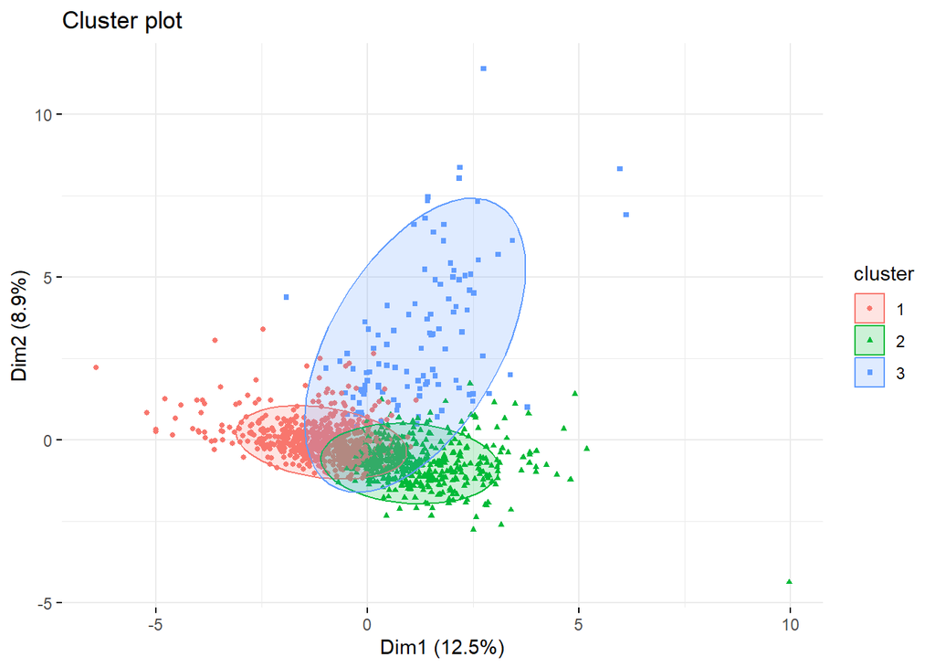

```r
variable_columns <- setdiff(columns_to_select, names(constant_cols))

# Standardisation
commune_scaled <- RPG_clean_2023 %>%
  select(all_of(variable_columns)) %>%
  scale()

# Détermination du nombre de cluster optimal
sil_data <- fviz_nbclust(commune_scaled, clara, method = "silhouette", correct.d=TRUE)
optimal_k <- which.max(sil_data$data$y)

# Clustering final
set.seed(123)
clustering <- clara(commune_scaled, k = optimal_k, samples = 50, pamLike = TRUE, correct.d = TRUE)

# Graphique
fviz_cluster(clustering,
             data = commune_scaled,
             ellipse.type = "t",
             geom = "point", pointsize = 1,
             ggtheme = theme_minimal())
```

*Note : certaines cultures ne sont pas prises en compte dans le clustering, car elles présentent une variance constante ie. ils s’agit de cultures qui n’ont pas été cultivées en 2023.*

Dim1 et Dim2 correspondent aux deux premières composantes principales. La première dimension explique 12,5% de la variance totale des données alors que la deuxième en explique 8,9%.

Il est possible d’étudier quelles variables influencent le plus Dim1 et Dim2, ce qui peut nous renseigner davantage sur la construction de ces clusters et de la visualisation finale.

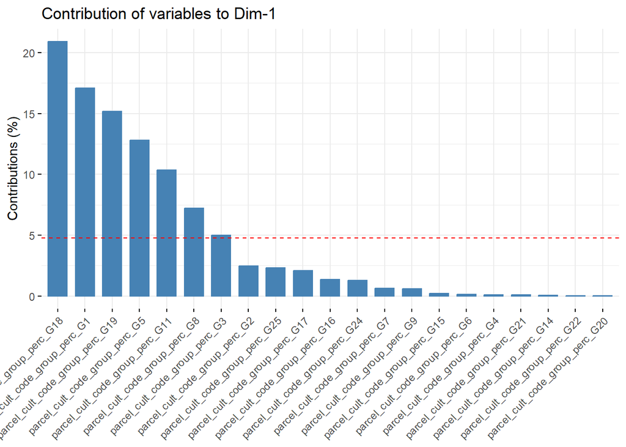

```r
res.pca <- PCA(commune_scaled, graph = FALSE)

# Contributions des variables à Dim1 et Dim2
fviz_contrib(res.pca, choice = "var", axes = 1)
```

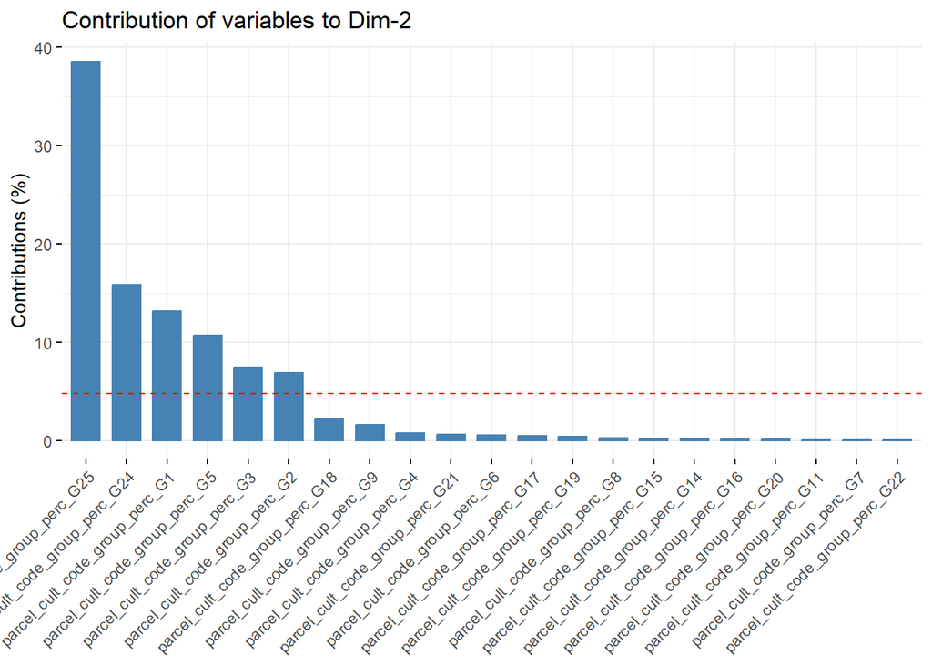

```r
fviz_contrib(res.pca, choice = "var", axes = 2)
```

Notons que nous avons ici de faibles proportions de variance expliquée par Dim1 et Dim2, cela s’explique par la multiplicité des dimensions qui existent dans notre cas. Je tend à supposer donc que l’interprétation en cluster en tout cas par la visualisation n’est peut-être pas tant représentative de l’ensemble des données que ça…

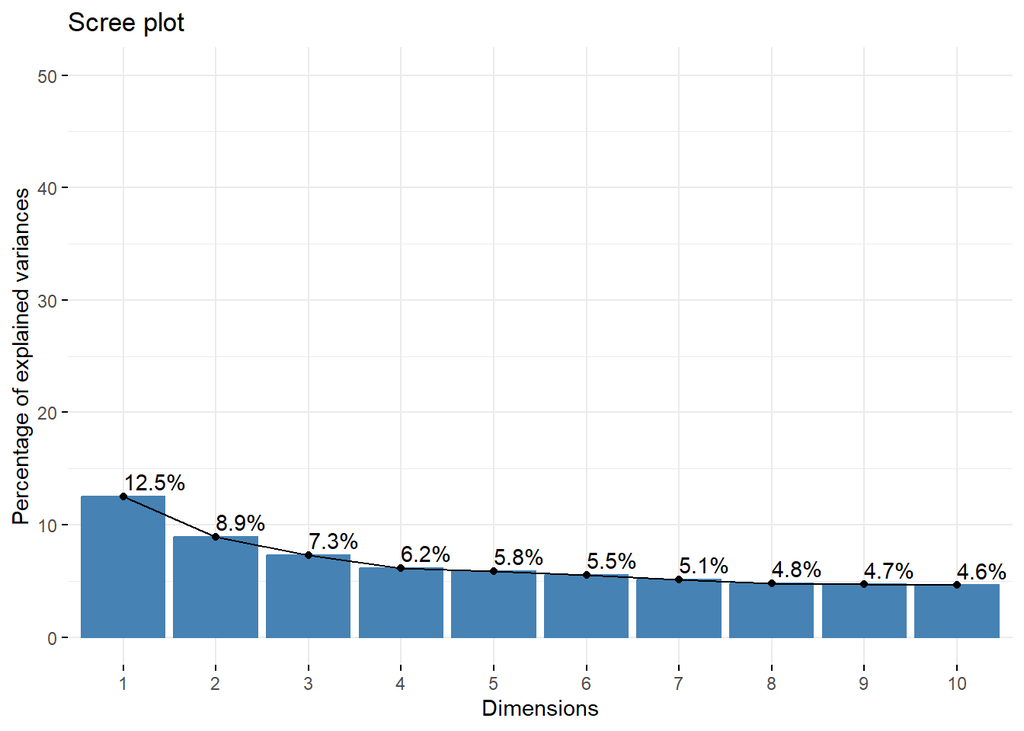

```r
fviz_eig(res.pca, addlabels = TRUE, ylim = c(0, 50))
```

## Analyse des profils moyens des clusters

```r
# Ajouter les clusters aux données originales
RPG_clean_2023 <- cbind(RPG_clean_2023, cluster = clustering$clustering)
```

```r
# Sélection des colonnes d'intérêt
columns_to_select <- paste0("parcel_cult_code_group_perc_G", 1:25)

# Moyennes par cluster
cluster_profiles <- RPG_clean_2023 %>%
  select(cluster, all_of(columns_to_select)) %>%
  group_by(cluster) %>%
  summarise(across(everything(), mean, na.rm = TRUE))
# Mettre en format long pour faciliter l’analyse
cluster_profiles_long <- cluster_profiles %>%
  pivot_longer(
    cols = -cluster,
    names_to = "groupe_culture",
    values_to = "moyenne"
  )

# Identifier les 3 groupes de culture les plus représentés dans chaque cluster
top_cultures_by_cluster <- cluster_profiles_long %>%
  group_by(cluster) %>%
  arrange(desc(moyenne), .by_group = TRUE) %>%
  slice_head(n = 3)
print(top_cultures_by_cluster)
```

```
## # A tibble: 9 × 3
## # Groups:   cluster [3]
##   cluster groupe_culture                  moyenne
##     <int> <chr>                             <dbl>
## 1       1 parcel_cult_code_group_perc_G18   0.345
## 2       1 parcel_cult_code_group_perc_G19   0.192
## 3       1 parcel_cult_code_group_perc_G2    0.174
## 4       2 parcel_cult_code_group_perc_G18   0.248
## 5       2 parcel_cult_code_group_perc_G2    0.203
## 6       2 parcel_cult_code_group_perc_G1    0.151
## 7       3 parcel_cult_code_group_perc_G25   0.238
## 8       3 parcel_cult_code_group_perc_G18   0.188
## 9       3 parcel_cult_code_group_perc_G2    0.165
```

La culture dominante dans les clusters 1 et 2 est la culture 18, correspondant aux **prairies permanentes** avec une représentation respectivement de 34%, 25%. Pour le cluster 3, les **prairies permanentes** se trouvent à la deuxième position du classement avec 19%. Cela paraît logique dans la mesure où il s’agit de la culture dominante d’une manière générale en Bretagne, avec la plus grande surface agricole totale dédiée au pâturage. Les trois clusters partagent aussi la culture 2, c’est-à-dire **le maïs**, comme dominante, en troisième position pour le cluster 1 et 3 avec 17% de représentation, alors qu’elle constitue la deuxième culture la plus dominante dans le cluster 2.

Renforçant l’idée d’une plus faible similarité entre le cluster 3 et les deux premiers, on trouve que la culture la plus dominante à 24% dans le cluster 3 est la culture 25, ie. **les légumes ou fleurs**. Nous pouvons alors regarder géographiquement comment est situé le cluster 3 pour conclure sur cette différence par rapport aux autres clusters.

## Visualisation cartographique du clustering

```r
library(dplyr)
library(sf)
# Charger le shapefile des communes
communes_sf <- st_read("data/shapefiles/communes-20220101.shp")
```

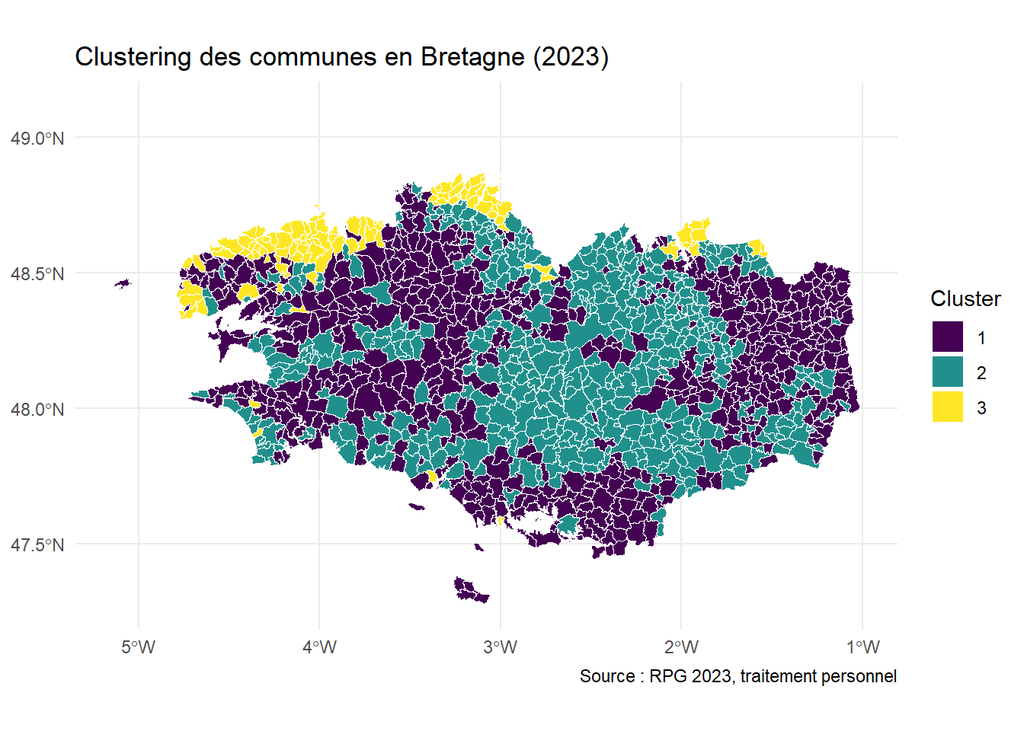

```r
# Joindre les données de cluster avec la géométrie + enlever les communes hors Bretagne
communes_sf <- communes_sf |>
  mutate(code_commune = as.character(insee))

RPG_map_data <- communes_sf |>
  left_join(RPG_clean_2023, by = "insee") |>
  na.omit()

# Visualiser la carte
ggplot(RPG_map_data) +
  geom_sf(aes(fill = as.factor(cluster)), color = "white", size = 0.1) +
  scale_fill_viridis_d(name = "Cluster") +
  theme_minimal() +
  labs(title = "Clustering des communes en Bretagne (2023)",
       caption = "Source : RPG 2023, traitement personnel")
```